# Model Performance And Fit - 3

One should look for what is and not what he thinks should be. (Albert Einstein)

# Warm up

- Check out this blog about how Neural Networks are used in everyday life: [Link](https://medium.com/analytics-vidhya/neural-networks-in-everyday-life-ca2b7cb37052)
- After reading, share your thoughts on the following questions:
  - According to you, what was the most interesting or surprising use of Neural Networks?
  - Do you know any other applications that use Neural Networks?

# Module completion checklist

| Objective | Complete |
| --- | --- |
| Introduce loss functions in TensorFlow |  |
| Implement backpropagation and gradient descent using TensorFlow |  |

# What is a loss function?

- The loss function *(or cost function)* is the function that describes the relationship between the neural network’s weights and the error
- The value returned by this function is called loss

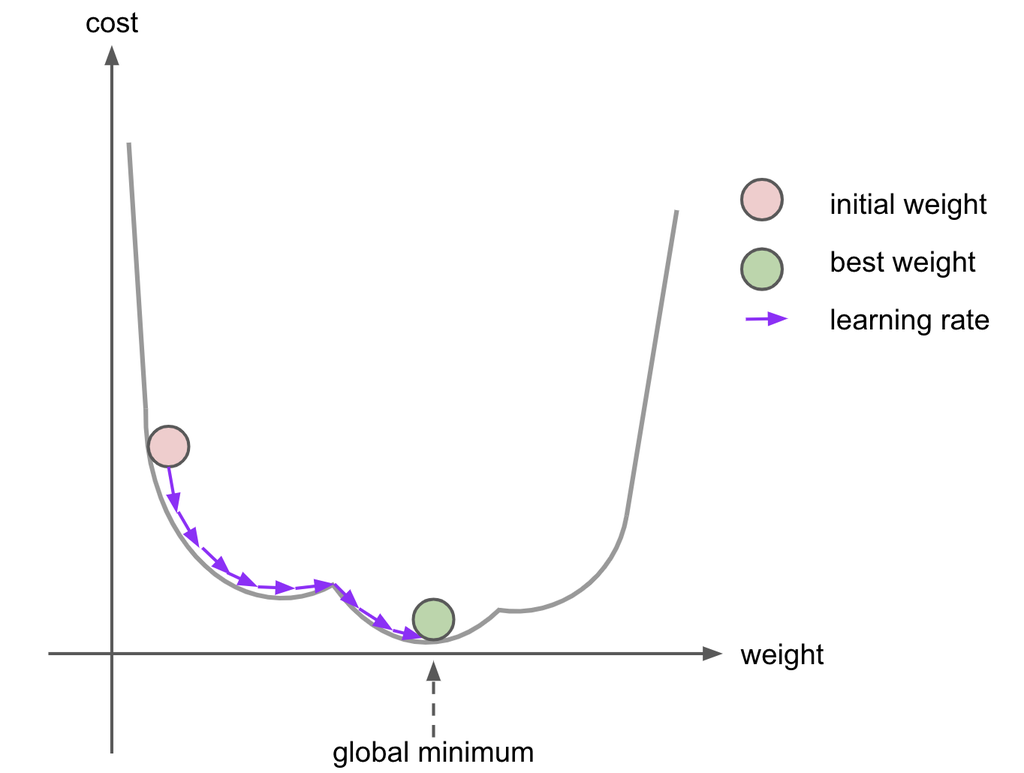

# Loss function (cont’d)

- We aim to find weights that **minimize the error**
- Optimizers within a neural network framework, such as Keras, operate on a given loss function to find the global minimum

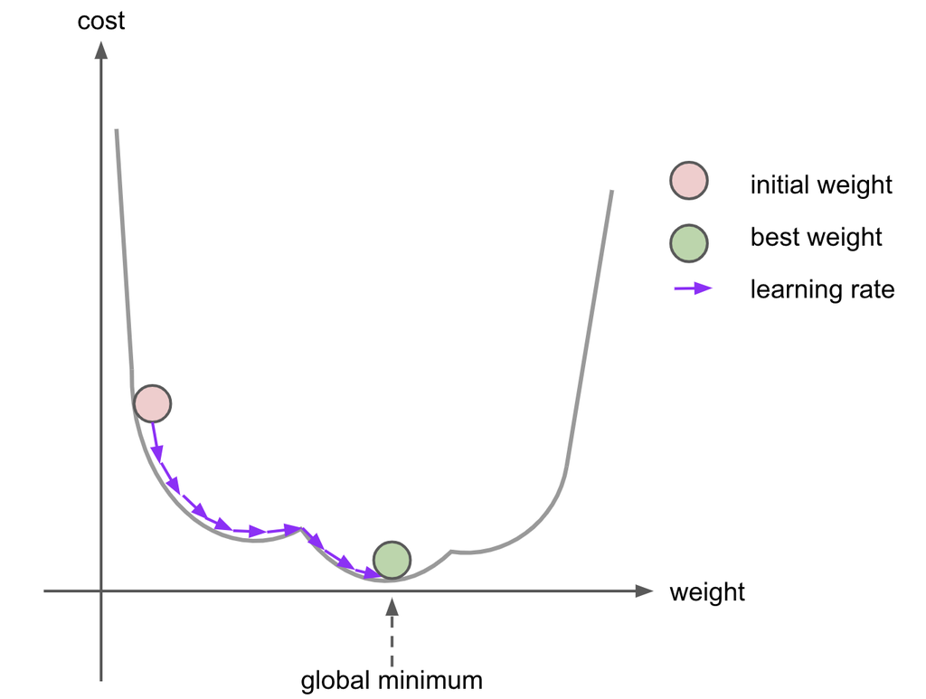

# Keras loss functions

- There is a long list of loss functions available in the `tf.keras.losses` module, including *BinaryCrossentropy*, *CategoricalCrossentropy*, *Cosinesimilarity*, *MSE*, *MAE*, and many more
- We will cover some common functions in class, but you can check out the rest on the [TensorFlow website](https://www.tensorflow.org/api_docs/python/tf/keras/losses)

[figure not shown]

# Loss function: binary crossentropy

- Binary crossentropy (a.k.a. log loss) is a metric that considers the **uncertainty of your prediction based on how much it varies from the actual label**
- It uses the **prediction probabilities of a class**, not the actual assigned class label
- It is widely used to assess conventional binary classification problems and be extended to multi-class classification problems

# Binary crossentropy: formula and intuition

- Log loss should be minimized, so **the smaller the number, the better** *(it can be $0$ or greater)*
- $L = \frac{-1}{N}\sum_{1}^{N}y_i\cdot\log(\hat{y_i}+(1-y_i))\cdot\log(1-\hat{y_i})$, where
  - $N$ is the number of observations in our model (i.e., the number of values in the `output` layer)
  - $y_i$ is the target value
  - $\hat{y_i}$ is the predicted value

# Binary crossentropy: formula and intuition (cont’d)

- The loss curve can be constructed to view how the value changes based on different probability thresholds

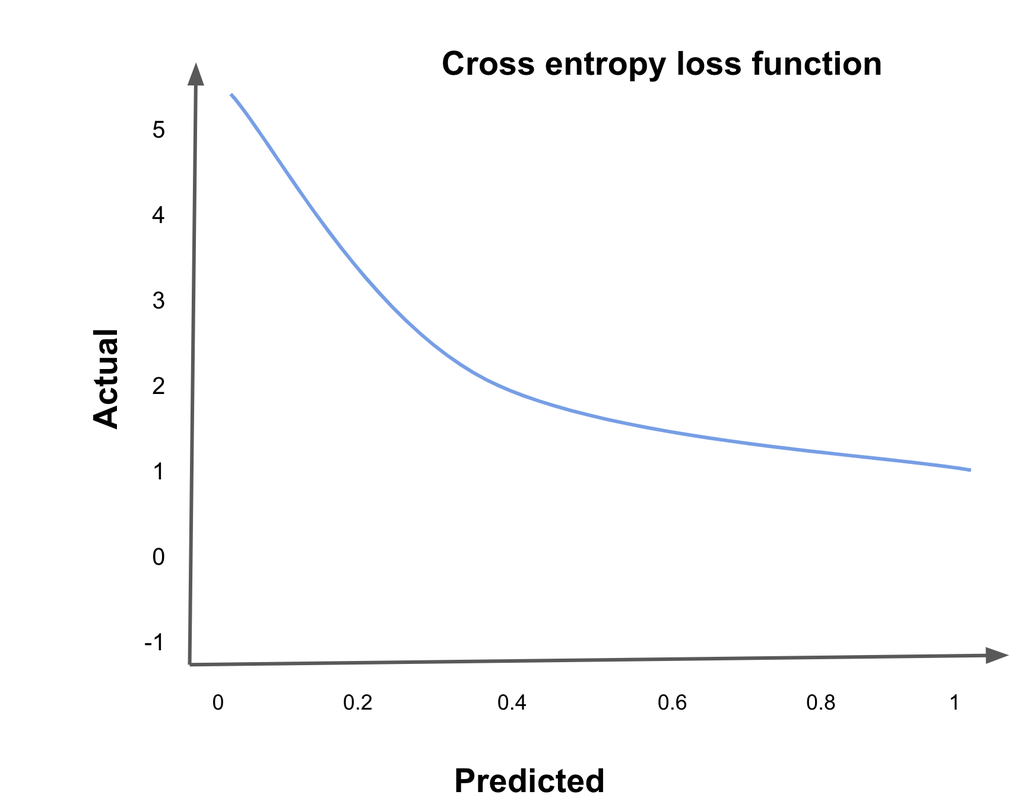

# Loss function: categorical crossentropy

- Categorical crossentropy is a loss function that is suited for multi-class classification problems
  - Multi-class classification problems involve more than two categories in the target variable
- It’s a generalized version of binary crossentropy and is computed in a similar fashion
- $L = \frac{-1}{N}\sum_{1}^{N}y_i\cdot\log(\hat{y_i})$, where
  - $N$ is the number of observations in our model (i.e., the number of values in the `output` layer)
  - $y_i$ is the target value
  - $\hat{y_i}$ is the predicted value

# Using categorical crossentropy in TensorFlow

- We need to provide the label inputs in the **one hot encoded format** while we use the categorical crossentropy as a loss function
- One hot encoding is a process that converts categorical variables to a numerical format
- For example, if we have a dataset that includes information on three car manufacturers *(BMW, Volkswagen, and Honda)*, the converted dataset would look as shown on the right

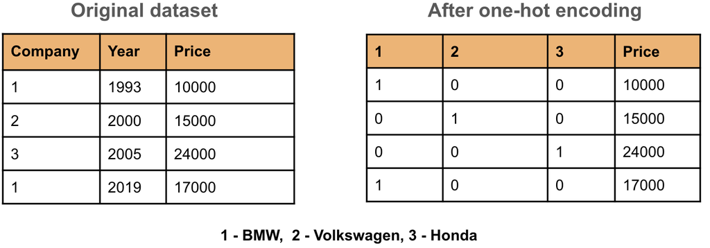

# Loss function: sparse categorical crossentropy

- If we wish to provide the categorical labels as integers instead of one hot encoding, we use the loss function - `SparseCategoricalCrossentropy`
- It’s the equation for a loss function is the same as categorical crossentropy

# Loss function: mean squared error (MSE)

- MSE is used as loss function in regression problems
- It’s measured as the average of squared difference between the predictions and the actual observations
- $MSE = \frac{\sum_{i=1}^{N}(y_i-\hat{y_i})^2}{N}$, where
  - $N$ is the number of observations in our model (i.e. the number of values in the `output` layer)
  - $y_i$ is the target value
  - $\hat{y_i}$ is the predicted value
- Due to squaring, predictions far away from the actual values are penalized heavily compared to predictions closer to actual values

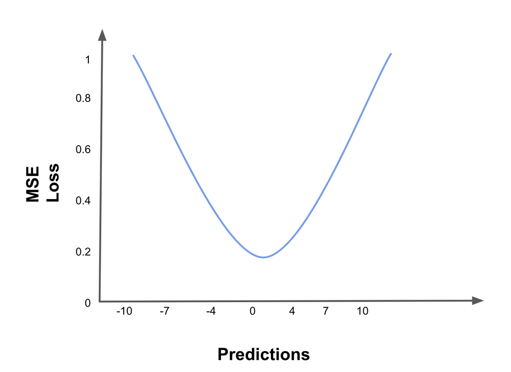

# Loss function: mean absolute error (MAE)

- MAE is also a loss function used in the regression problems
- It is calculated by taking the mean of the absolute differences between predicted and the actual values
- $MAE = (\frac{1}{N})\sum_{i=1}^{N}\left | y_{i} - x_{i} \right |$, where
  - $N$ is the number of observations in our model (i.e. the number of values in the `output` layer)
  - $y_i$ is the target value
  - $\hat{y_i}$ is the predicted value
- MAE is preferred to be chosen as the loss function when there are more outliers in the training data

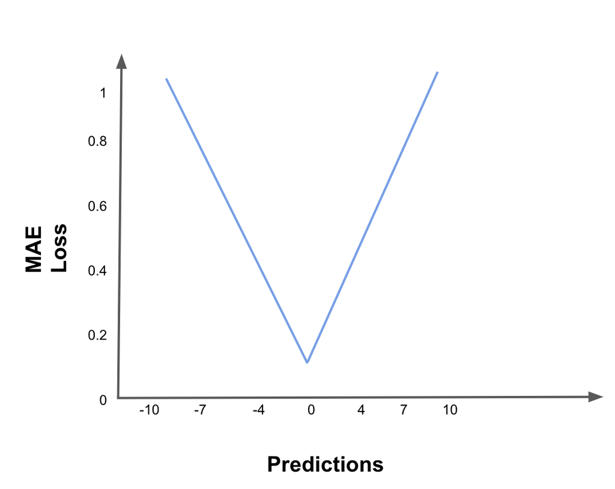

# Loss functions summary

| Loss function | Use case |
| --- | --- |
| Binary crossentropy | Binary classification problems |
| Categorical crossentropy | Multi-class classification problems with target labels in one-hot-encoding format |
| Sparse categorical crossentropy | Multi-class classification with target labels as integers |
| Mean squared error (MSE) | Regression problems |
| Mean absolute error | Regression problems |

# Module completion checklist

| Objective | Complete |
| --- | --- |
| Introduce loss functions in TensorFlow | **✔** |
| Implement backpropagation and gradient descent using TensorFlow |  |

# Overview

- In this section, we will reinforce our understanding of neural network components and illustrate the mechanics of **backpropagation on a simple feedforward neural network**
- Note: The gradients that we will deal with today will be vector representations of the derivative of the activation function

# Generate some fake data

- Let’s generate some fake data and train our neural network
- Imagine that our data is drawn from a linear function:
  - $y = 3.5*studyhours + 50$, where $3.5$ is our true `weight` and $50$ is our true `bias`

```python
TRUE_W = 3.5         #<- true weight
TRUE_b = 50.0        #<- true bias
NUM_EXAMPLES = 1000  #<- number of observations
```

```python
# Simulate inputs and noise from normal distribution.
inputs = tf.random.normal(shape=[NUM_EXAMPLES])
noise = tf.random.normal(shape=[NUM_EXAMPLES])
```

```python
# Compute the outputs based on our equation.
outputs = inputs * TRUE_W + TRUE_b + noise
```

# Neural network architecture

- Let’s create a neural network class called `Model`
  - This is essentially a linear regression whose coefficients are trained by gradient descent
  - In practice, gradient descent works with much more complex functions within multi-layer networks

```python
# Define model.
class Model(object):

  def __init__(self):
    self.W = tf.Variable(8.0)   #<- initial weight
    self.b = tf.Variable(40.0)  #<- initial bias

  def __call__(self, x):
    return self.W * x + self.b #<- compute the equation
```

```python
# Initialize the model.
model = Model()
```

```python
# Check if it outputs correct results.
assert model(3.0).numpy() == 64.0
```

# Loss function

- Here we will use Mean Squared Error (MSE), because it is a regression problem
- We are trying to predict a continuous target $y$

```python
# Define loss function.
def loss(target_y, predicted_y):
  "MSE"
  return tf.reduce_mean(tf.square(target_y - predicted_y))
```

# Initial weights

- The initial weights were chosen by us in this instance
- However, in practice, weights are initialized randomly

```python
print('Current loss: %1.6f' % loss(model(inputs),
       outputs).numpy())
```

```
Current loss: 121.196548
```

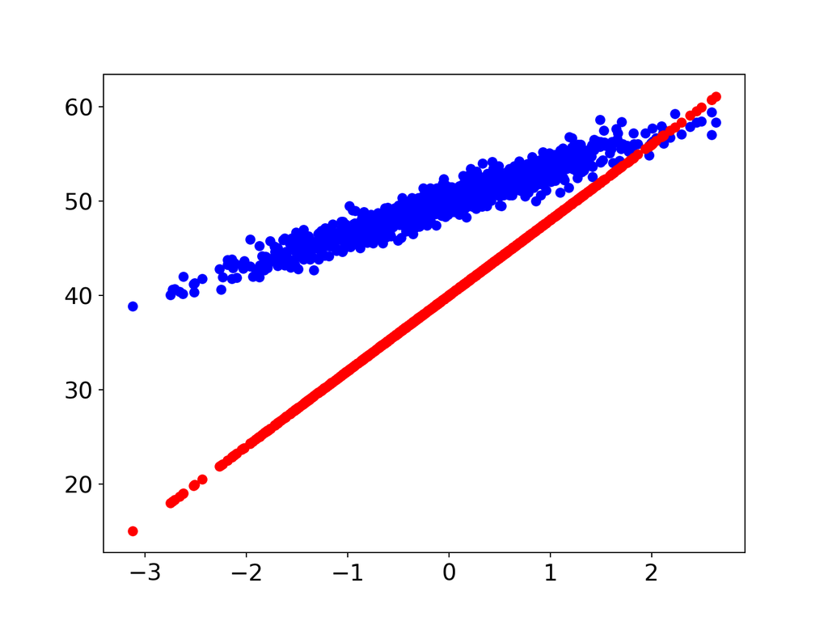

```python
plt.scatter(inputs, outputs, c = 'b')
plt.scatter(inputs, model(inputs), c = 'r')
plt.show()
```

# Update weights based on gradient

- Due to the high complexity of the models and their non-linearity, it is common for gradient descent to get stuck in a local minimum, but there are ways to combat this:
  - Stochastic Gradient Descent
  - More advanced GD-based optimizers
- Now let’s define the training function

```python
# Define the train function for our NN.
def train(model, inputs, outputs, learning_rate):

  with tf.GradientTape() as t:
     current_loss = loss(outputs, model(inputs)) #<- compute loss

  # Compute partial derivatives:
  # how much does a particular obvs + W + b contribute to that loss.
  dW, db = t.gradient(current_loss, [model.W, model.b])

  # Update with new weights and bias using our learning rate.
  model.W.assign_sub(learning_rate * dW)
  model.b.assign_sub(learning_rate * db)
```

# Train the neural network

```python
model = Model()

# Store some history of weights.
Ws, bs = [], []
epochs = range(15)

for epoch in epochs:
  Ws.append(model.W.numpy())
  bs.append(model.b.numpy())
  current_loss = loss(outputs, model(inputs))

  train(model, inputs, outputs, learning_rate=0.1)
  print('Epoch %2d: W=%1.2f b=%1.2f loss=%2.5f' % (epoch, Ws[-1], bs[-1], current_loss))
```

```
Epoch  0: W=8.00 b=40.00 loss=121.19655
Epoch  1: W=7.13 b=42.01 loss=78.17503
Epoch  2: W=6.43 b=43.61 loss=50.55076
Epoch  3: W=5.86 b=44.89 loss=32.81210
Epoch  4: W=5.41 b=45.92 loss=21.42066
Epoch  5: W=5.04 b=46.74 loss=14.10485
Epoch  6: W=4.74 b=47.40 loss=9.40621
Epoch  7: W=4.49 b=47.93 loss=6.38827
Epoch  8: W=4.30 b=48.35 loss=4.44973
Epoch  9: W=4.14 b=48.68 loss=3.20444
Epoch 10: W=4.01 b=48.95 loss=2.40444
Epoch 11: W=3.91 b=49.17 loss=1.89046
Epoch 12: W=3.82 b=49.34 loss=1.56022
Epoch 13: W=3.76 b=49.48 loss=1.34803
Epoch 14: W=3.70 b=49.59 loss=1.21167
```

# Inspect the results

```python
plt.plot(epochs, Ws, 'r', epochs, bs, 'b')
plt.plot([TRUE_W] * len(epochs), 'r--',
         [TRUE_b] * len(epochs), 'b--')
plt.legend(['W', 'b', 'True W', 'True b'])
plt.show()
```

- The weights and the bias converged very close to their true values

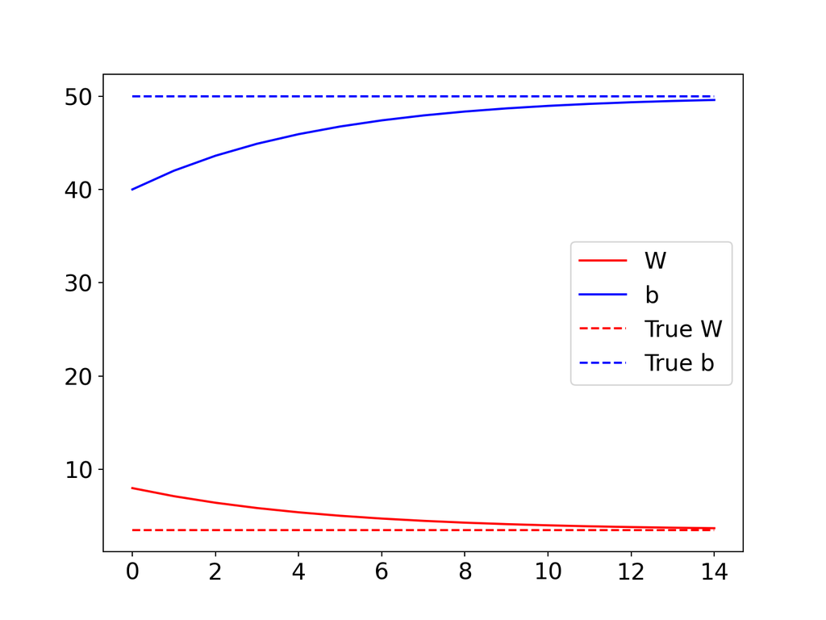

# Inspect the results (cont’d)

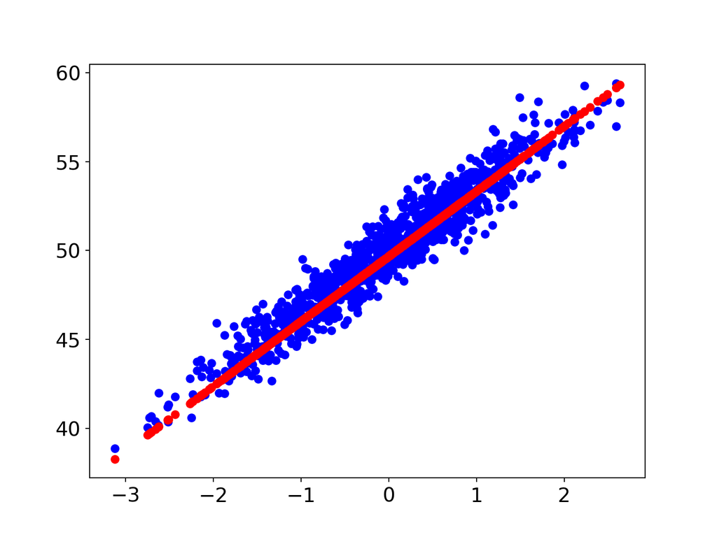

```python
plt.scatter(inputs, outputs, c='b')
plt.scatter(inputs, model(inputs), c='r')
plt.show()
```

# Inspect the results (cont’d)

```python
print('Current loss: %1.6f' % loss(model(inputs), outputs).numpy())
```

```
Current loss: 1.124042
```

- The fit of the model to our data is now very good as opposed to the initial starting point
- We can also see that in just `15` epochs our very simple neural network was able to go from a loss of `100+` down to just over `1`!

# Knowledge check

# Module completion checklist

| Objective | Complete |
| --- | --- |
| Introduce loss functions in TensorFlow | **✔** |
| Implement backpropagation and gradient descent using TensorFlow | **✔** |

# Congratulations on completing this module!